# R studio exercise 3: logistic regression

### Basic information about the data set

In this exercise I use a dataset comprised of datasets of Portuguese students of math and Portuguese language in secondary education. The original datasets can be found from [here](https://archive.ics.uci.edu/ml/datasets/Student+Performance). The following chunks of code read in the dataset from my local folder and print out the names of the variables

```r
alc<-read.csv(file = "data/alc.csv", header = TRUE, sep=",")
colnames(alc)
```

```
##  [1] "school"     "sex"        "age"        "address"    "famsize"
##  [6] "Pstatus"    "Medu"       "Fedu"       "Mjob"       "Fjob"
## [11] "reason"     "nursery"    "internet"   "guardian"   "traveltime"
## [16] "studytime"  "failures"   "schoolsup"  "famsup"     "paid"
## [21] "activities" "higher"     "romantic"   "famrel"     "freetime"
## [26] "goout"      "Dalc"       "Walc"       "health"     "absences"
## [31] "G1"         "G2"         "G3"         "alc_use"    "high_use"
```

**Explanations to the variables**

- “school” = student’s school
- “sex” = student’s sex
- “age” = student’s age
- “address” = student’s home address
- “famsize” = family size
- “Pstatus” = parent’s cohabitation status (living together or apart),
- “Medu” = mother’s education
- “Fedu” = father’s education
- “Mjob” = mother’s job
- “Fjob”= father’s job
- “reason” = reason to choose this school
- “nursery” = attended nursery school (yes or no)
- “internet” = Internet access at home
- “guardian” = student’s guardian (mother, father or other)
- “traveltime” = home to school travel time
- “studytime” = weekly study time
- “failures” = number of past class failures
- “schoolsup” = extra educational support
- “famsup” = family educational support
- “paid” = extra paid classes within the course subject
- “activities” = extra-curricular activities
- “higher” = wants to take higher education
- “romantic” = with a romantic relationship
- “famrel” = quality of family relationships
- “freetime” = free time after school
- “goout” = going out with friends
- “Dalc” = workday alcohol consumption
- “Walc” = weekend alcohol consumption
- “health” = current health status
- “absences” = number of school absences
- “G1” = first period grade
- “G2” = second period grade
- “G3” = final grade
- “alc_use” = average daily alcohol consumption (average of weekday and weekend consumption)
- “high_use” = TRUE is alc_use>2, FALSE if alc_use<2 ([Likert Scale](https://en.wikipedia.org/wiki/Likert_scale))

### Variables chose for the analysis and the hypotheses related to them

I will look into how the students’ alcohol use is related to the variables “sex” (M or F), “Pstatus” (A or T), “guardian” (mother, father or other) and “goout” (Likert scale 1-5). My hypotheses for the chosen variables are, that high use of alcohol is more common for

**1. male than female students,**  
**2. students whose parents live apart, than students whose parents live together**  
**3. students whose guardian is someone else than either of the parents**  
**4. students who go out with friends actively compared to those who don’t**

### Analyses

I will choose only the columns that I need for the analyses and will create a set called alcohol out of them. I need package ‘dplyr’ for this.

```r
library(dplyr)
keep_columns <- c("sex","Pstatus", "guardian", "goout", "high_use")
alcohol <- select(alc, one_of(keep_columns))
```

Next I will graphically examine the variables. The following code draws bar plots of each variable. I will need packages ‘tidyr’, ‘dplyr’ and ‘ggplot2’ for plotting. I have installed the packages beforehand and called ‘dplyr’ already earlier.

```r
library(tidyr)
```

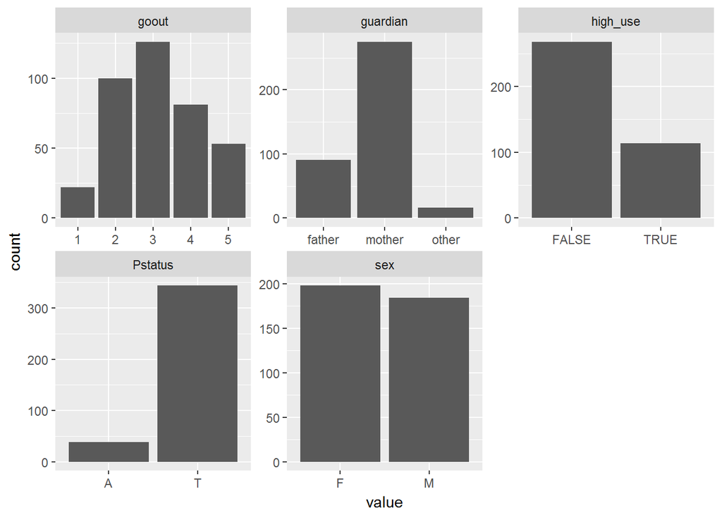

```r
library(ggplot2)
gather(alcohol) %>% ggplot(aes(value)) + facet_wrap("key", scales = "free") + geom_bar()
```

The “goout” variable most often gets the value 3, which is an average value: not very high but not very low either. Mother was the most common guardian for students, followed by father. Some students had marked ‘other’ as guardian. Although high consumption of alcohol also appeared among students, low or normal consumption was more common. Clearly a bigger proportion of students had parents living together than parents living apart, while the gender distribution of students was almost equal.

Next I will examine the relationships between variables by crosstabulation.

```r
table(high_use = alcohol$high_use, sex = alcohol$sex)
```

```
##         sex
## high_use   F   M
##    FALSE 156 112
##    TRUE   42  72
```

```r
table(high_use = alcohol$high_use, Pstatus = alcohol$Pstatus)
```

```
##         Pstatus
## high_use   A   T
##    FALSE  26 242
##    TRUE   12 102
```

```r
table(high_use = alcohol$high_use, guardian = alcohol$guardian)
```

```
##         guardian
## high_use father mother other
##    FALSE     61    198     9
##    TRUE      30     77     7
```

```r
table(high_use = alcohol$high_use, go_out = alcohol$goout)
```

```
##         go_out
## high_use   1   2   3   4   5
##    FALSE  19  84 103  41  21
##    TRUE    3  16  23  40  32
```

To understand what these tables tell I calculated the percentages of students with high alcohol use for each variable statement. The calculations are below.

```r
female_high <- (42/(156+42))*100
female_high
```

```
## [1] 21.21212
```

```r
male_high <-(72/(112+72))*100
male_high
```

```
## [1] 39.13043
```

```r
parents_apart_high <- (12/(26+12))*100
parents_apart_high
```

```
## [1] 31.57895
```

```r
parents_together_high <- (102/(242+102))*100
parents_together_high
```

```
## [1] 29.65116
```

```r
guardian_father_high <- (30/(61+30))*100
guardian_father_high
```

```
## [1] 32.96703
```

```r
guardian_mother_high <- (77/(198+77))*100
guardian_mother_high
```

```
## [1] 28
```

```r
guardian_other_high <- (7/(7+9))*100
guardian_other_high
```

```
## [1] 43.75
```

```r
go_out_1 <- (3/(19+3))*100
go_out_1
```

```
## [1] 13.63636
```

```r
go_out_2 <- (16/(84+16))*100
go_out_2
```

```
## [1] 16
```

```r
go_out_3 <- (23/(103+23))*100
go_out_3
```

```
## [1] 18.25397
```

```r
go_out_4 <- (40/(41+40))*100
go_out_4
```

```
## [1] 49.38272
```

```r
go_out_5 <- (32/(21+32))*100
go_out_5
```

```
## [1] 60.37736
```

Based on these percentages hypothesis number one is supported: 39 % of male students and 21 % of female students use high amounts of alcohol. The percentages for high alcohol use in students whose parents are apart (32 %) versus students whose parents live together (30 %) are almost similar, so hypothesis number two doesn’t seem to be very strongly supported. Hypothesis three is supported, since the amount of high alcohol users when the guardian is other is 44 %, which is clearly higher than when the guardian is father (33 %) or mother (28 %). Also the fourth hypothesis is supported, since the amount of high drinkers clearly increases with the amount of going out. Of course, a more thorough examination is needed, as based on this information it is not possible to tell what differences are statistically significant and what are not.

### Building a logistic regression model

In order to statistically examine the variables and their dependance from each other I am going to use logistic regression and build a model.

```r
m <- glm(high_use ~ sex + Pstatus + guardian + goout, data = alcohol, family = "binomial")
summary(m)
```

```
##
## Call:
## glm(formula = high_use ~ sex + Pstatus + guardian + goout, family = "binomial",
##     data = alcohol)
##
## Deviance Residuals:
##     Min       1Q   Median       3Q      Max
## -1.6778  -0.8245  -0.5846   0.8872   2.3178
##
## Coefficients:
##                Estimate Std. Error z value Pr(>|z|)
## (Intercept)     -3.3914     0.6143  -5.521 3.37e-08 ***
## sexM             0.8576     0.2481   3.457 0.000546 ***
## PstatusT        -0.2189     0.4084  -0.536 0.591942
## guardianmother  -0.3977     0.2920  -1.362 0.173226
## guardianother    0.3346     0.6044   0.554 0.579917
## goout            0.7759     0.1197   6.482 9.03e-11 ***
## ---
## Signif. codes:  0 '***' 0.001 '**' 0.01 '*' 0.05 '.' 0.1 ' ' 1
##
## (Dispersion parameter for binomial family taken to be 1)
##
##     Null deviance: 465.68  on 381  degrees of freedom
## Residual deviance: 399.46  on 376  degrees of freedom
## AIC: 411.46
##
## Number of Fisher Scoring iterations: 4
```

In order to see all coefficients of variable “sex” I will change the model and add -1. This way R will plot all coefficients and no intercept at all.

```r
m <- glm(high_use ~ sex + Pstatus + guardian + goout-1  , data = alcohol, family = "binomial")
summary(m)
```

```
##
## Call:
## glm(formula = high_use ~ sex + Pstatus + guardian + goout - 1,
##     family = "binomial", data = alcohol)
##
## Deviance Residuals:
##     Min       1Q   Median       3Q      Max
## -1.6778  -0.8245  -0.5846   0.8872   2.3178
##
## Coefficients:
##                Estimate Std. Error z value Pr(>|z|)
## sexF            -3.3914     0.6143  -5.521 3.37e-08 ***
## sexM            -2.5338     0.5959  -4.252 2.12e-05 ***
## PstatusT        -0.2189     0.4084  -0.536    0.592
## guardianmother  -0.3977     0.2920  -1.362    0.173
## guardianother    0.3346     0.6044   0.554    0.580
## goout            0.7759     0.1197   6.482 9.03e-11 ***
## ---
## Signif. codes:  0 '***' 0.001 '**' 0.01 '*' 0.05 '.' 0.1 ' ' 1
##
## (Dispersion parameter for binomial family taken to be 1)
##
##     Null deviance: 529.56  on 382  degrees of freedom
## Residual deviance: 399.46  on 376  degrees of freedom
## AIC: 411.46
##
## Number of Fisher Scoring iterations: 4
```

It seems that the coefficients of “sex” are statistically significantly different from zero, which is what the Wald test in R tests for factorial variables ([ref.](https://stats.stackexchange.com/questions/60817/significance-of-categorical-predictor-in-logistic-regression)).

I noticed that R only prints all coefficients of the first factorial variable, which comes after ~ symbol in the code. I am not sure if there is a prettier way of doing this, but in order to see all coefficients of the factorial variables " sex“,”Pstatus" and “guardian”, I will create different models so that I just simply change the order of variables after ~ in the code. I will later also check the overall meaning of each factorial variable to the model. The variable “goout” is an integer, and I can directly see that it has a low p-value so it seems to be explaining high use of alcohol well. But to start with:

Here I check the coefficients of variable Pstatus:

```r
m3 <- glm(high_use ~  Pstatus + guardian + goout + sex -1, data = alcohol, family = "binomial")
summary(m3)
```

```
##
## Call:
## glm(formula = high_use ~ Pstatus + guardian + goout + sex - 1,
##     family = "binomial", data = alcohol)
##
## Deviance Residuals:
##     Min       1Q   Median       3Q      Max
## -1.6778  -0.8245  -0.5846   0.8872   2.3178
##
## Coefficients:
##                Estimate Std. Error z value Pr(>|z|)
## PstatusA        -3.3914     0.6143  -5.521 3.37e-08 ***
## PstatusT        -3.6103     0.4861  -7.427 1.11e-13 ***
## guardianmother  -0.3977     0.2920  -1.362 0.173226
## guardianother    0.3346     0.6044   0.554 0.579917
## goout            0.7759     0.1197   6.482 9.03e-11 ***
## sexM             0.8576     0.2481   3.457 0.000546 ***
## ---
## Signif. codes:  0 '***' 0.001 '**' 0.01 '*' 0.05 '.' 0.1 ' ' 1
##
## (Dispersion parameter for binomial family taken to be 1)
##
##     Null deviance: 529.56  on 382  degrees of freedom
## Residual deviance: 399.46  on 376  degrees of freedom
## AIC: 411.46
##
## Number of Fisher Scoring iterations: 4
```

The two coefficients of “Pstatus”, ‘apart’ and ‘together’ seem to be statistically significantly different from zero.

Next I will check variable “guardian”.

```r
m4 <- glm(high_use ~ guardian + goout + sex + Pstatus-1, data = alcohol, family = "binomial")
summary(m4)
```

```
##
## Call:
## glm(formula = high_use ~ guardian + goout + sex + Pstatus - 1,
##     family = "binomial", data = alcohol)
##
## Deviance Residuals:
##     Min       1Q   Median       3Q      Max
## -1.6778  -0.8245  -0.5846   0.8872   2.3178
##
## Coefficients:
##                Estimate Std. Error z value Pr(>|z|)
## guardianfather  -3.3914     0.6143  -5.521 3.37e-08 ***
## guardianmother  -3.7891     0.5784  -6.551 5.72e-11 ***
## guardianother   -3.0569     0.7644  -3.999 6.36e-05 ***
## goout            0.7759     0.1197   6.482 9.03e-11 ***
## sexM             0.8576     0.2481   3.457 0.000546 ***
## PstatusT        -0.2189     0.4084  -0.536 0.591942
## ---
## Signif. codes:  0 '***' 0.001 '**' 0.01 '*' 0.05 '.' 0.1 ' ' 1
##
## (Dispersion parameter for binomial family taken to be 1)
##
##     Null deviance: 529.56  on 382  degrees of freedom
## Residual deviance: 399.46  on 376  degrees of freedom
## AIC: 411.46
##
## Number of Fisher Scoring iterations: 4
```

And yes, ‘father’, ‘mother’ and ‘other’ all seem to be significantly different from zero.

The fact that all the coeffiecients that I tested above are different from zero mean that the variables are probably not completely meaningless to the model. In order to test that I will now perform a likelihood ratio test so, that I separately test the model with and without each of the factorial varibale.

First I check variable “sex”

```r
m1<-glm(high_use ~ sex + Pstatus + guardian + goout, data = alcohol, family = "binomial")
m2<-glm(high_use ~ Pstatus + guardian + goout, data = alcohol, family = "binomial")
anova(m1, m2, test="LRT")
```

```
## Analysis of Deviance Table
##
## Model 1: high_use ~ sex + Pstatus + guardian + goout
## Model 2: high_use ~ Pstatus + guardian + goout
##   Resid. Df Resid. Dev Df Deviance  Pr(>Chi)
## 1       376     399.46
## 2       377     411.75 -1  -12.286 0.0004564 ***
## ---
## Signif. codes:  0 '***' 0.001 '**' 0.01 '*' 0.05 '.' 0.1 ' ' 1
```

The likelihood ratio test is highly significant, meaning that the variable “sex” should be kept in the model. Next I test the meaning of variable “Pstatus”

```r
m1<-glm(high_use ~  Pstatus + guardian + goout + sex -1, data = alcohol, family = "binomial")
m2<-glm(high_use ~ guardian + goout + sex, data = alcohol, family = "binomial")
anova(m1, m2, test="LRT")
```

```
## Analysis of Deviance Table
##
## Model 1: high_use ~ Pstatus + guardian + goout + sex - 1
## Model 2: high_use ~ guardian + goout + sex
##   Resid. Df Resid. Dev Df Deviance Pr(>Chi)
## 1       376     399.46
## 2       377     399.74 -1 -0.28305   0.5947
```

It looks like “Pstatus” is not a meaningful model parameter. Let’s see if “guardian” is.

```r
m1<-glm(high_use ~ guardian + goout + sex + Pstatus-1, data = alcohol, family = "binomial")
m2<-glm(high_use ~ goout + sex + Pstatus-1, data = alcohol, family = "binomial")
anova(m1, m2, test="LRT")
```

```
## Analysis of Deviance Table
##
## Model 1: high_use ~ guardian + goout + sex + Pstatus - 1
## Model 2: high_use ~ goout + sex + Pstatus - 1
##   Resid. Df Resid. Dev Df Deviance Pr(>Chi)
## 1       376     399.46
## 2       378     402.57 -2  -3.1068   0.2115
```

For modelling purposes “guardian” doesn’t seem to be important either. At the moment it looks like the important explaining variables to be kept in the model are “sex” and “goout”. I will now adjust the model to its final form, show its summary and present its odds ratios

```r
m <- glm(high_use ~ sex + goout, data = alcohol, family ="binomial")
summary(m)
```

```
##
## Call:
## glm(formula = high_use ~ sex + goout, family = "binomial", data = alcohol)
##
## Deviance Residuals:
##     Min       1Q   Median       3Q      Max
## -1.5599  -0.8726  -0.6260   0.8382   2.4893
##
## Coefficients:
##             Estimate Std. Error z value Pr(>|z|)
## (Intercept)  -3.8130     0.4529  -8.420  < 2e-16 ***
## sexM          0.8736     0.2466   3.543 0.000396 ***
## goout         0.7609     0.1181   6.441 1.19e-10 ***
## ---
## Signif. codes:  0 '***' 0.001 '**' 0.01 '*' 0.05 '.' 0.1 ' ' 1
##
## (Dispersion parameter for binomial family taken to be 1)
##
##     Null deviance: 465.68  on 381  degrees of freedom
## Residual deviance: 402.74  on 379  degrees of freedom
## AIC: 408.74
##
## Number of Fisher Scoring iterations: 4
```

```r
OR <- coef(m) %>% exp
CI<-confint(m) %>% exp
cbind(OR, CI)
```

```
##                     OR       2.5 %     97.5 %
## (Intercept) 0.02208168 0.008754964 0.05186666
## sexM        2.39559680 1.484457552 3.91015147
## goout       2.14025612 1.708110942 2.71701439
```

I have trouble in understanding odds ratios. If interpret the last rows of the previous output correctly, if a student is a male, the odds for him to be in using high amount of alcohol is twice as high as if a student is a female. And the confidence intervals mean that in 95 % of the cases the odds are between 1.48 and 3.91. I am even more unsure how to interpret the odds of variable “goout”. I believe it is something like that if a student goes out often and is a male, the odds of the student to be using high amounts of alcohol is about twice as much as for a student who does not go out often. And in 95 % of the cases the odds are between 1.7 and 2.7. I am really struggling with this interpretation, so the odds that I have done something wrong are very high…

### The predictive power of the model

I will now look into the variables “sex” and “goout” that I chose for the model. Next I will provide a 2x2 cross tabulation of predictions versus the actual values.

```r
probabilities <- predict(m, type = "response")
alcohol <- mutate(alcohol, probability = probabilities)
alcohol <- mutate(alcohol, prediction = probability>0.5 )
select(alcohol, sex, goout, high_use, probability, prediction) %>% tail(10)
```

```
##     sex goout high_use probability prediction
## 373   M     2    FALSE  0.19505008      FALSE
## 374   M     3     TRUE  0.34150419      FALSE
## 375   F     3    FALSE  0.17795995      FALSE
## 376   F     3    FALSE  0.17795995      FALSE
## 377   F     2    FALSE  0.09185806      FALSE
## 378   F     4    FALSE  0.31662945      FALSE
## 379   F     2    FALSE  0.09185806      FALSE
## 380   F     1    FALSE  0.04512769      FALSE
## 381   M     5     TRUE  0.70375694       TRUE
## 382   M     1     TRUE  0.10170252      FALSE
```

```r
table(high_use = alcohol$high_use, prediction = alcohol$prediction)
```

```
##         prediction
## high_use FALSE TRUE
##    FALSE   251   17
##    TRUE     63   51
```

I will also compute the training error (the total proportion of inaccurately classified individuals).

```r
loss_func <- function(class, prob) {
  n_wrong <- abs(class - prob) > 0.5
  mean(n_wrong)
}

loss_func(class = alcohol$high_use, prob = alcohol$probability)
```

```
## [1] 0.2094241
```

I would say that the total proportion of inaccurately classified individuals in the predictions that the model does is quite low. Thus, the model is working fairly well.